# 2100093010_吕东炫_个人作业二

## （1）Geographical Data Visualization

### （1.1）Global Connections: A Glimpse into Institutional Partnerships in Research

## （2）Temporal Data Visualization

### （2.1）Annual Publication Count: A Timeline of Research Papers

### （2.2）Monthly PACS Breakdown: A Heatmap of Research Publications (1977 - 2013)

# -------------------------------------------------------------------------------------------------------------

* 在本次作业中，我主要关注了时间和地理维度的可视化。我使用了三个数据集来展示不同年份的论文发表趋势、月度的PACS分类下的论文发表情况，以及全球不同机构间的合作关系。考虑到citationPairs.csv数据集主要描述的是论文间的引用关系，而不是时间或地理位置，因此在本次作业的主题和目的下，该数据集似乎不太适用。虽然理论上可以尝试根据引用关系绘制时间序列的引用图，但这样的可视化可能不如其他数据集中直接关于时间和地理位置的信息那么直观和有意义。为了保持报告的聚焦和清晰，我决定暂时不使用citationPairs.csv数据集。

## （1）Geographical Data Visualization

### Global Connections: A Glimpse into Institutional Partnerships in Research

### Dataset：doiAuthorAffiliation.jsonl

1、可视化结果的展示

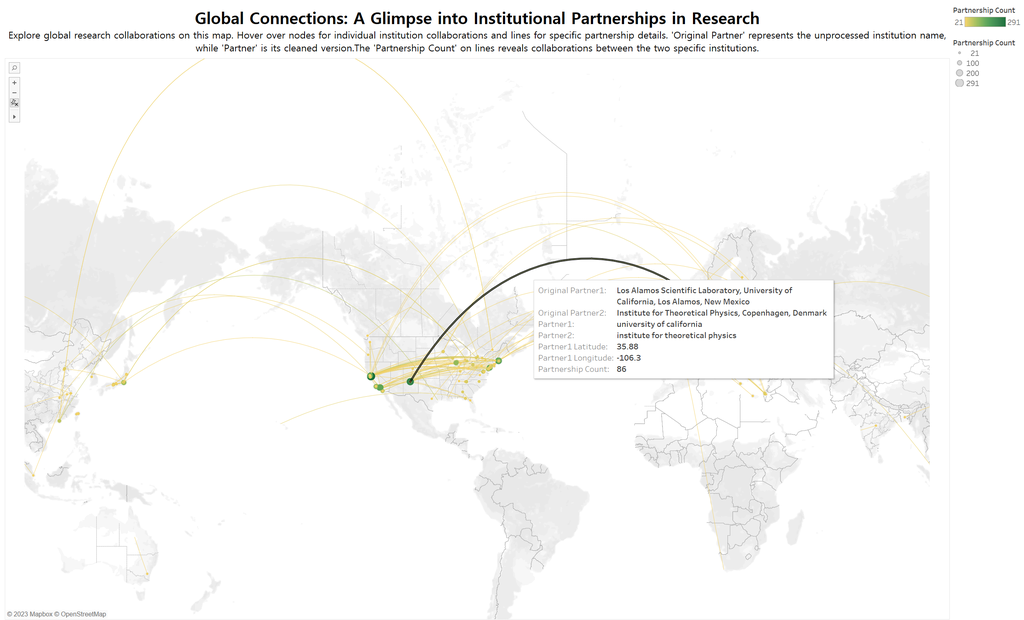

```python
# Global Connections: A Glimpse into Institutional Partnerships in Research 可视化展示
from IPython.display import Image
Image(filename='Geographical Data Visualization.png')
```

2、可视化结果的解读

在这幅地理可视化图中，各个机构依据其经纬度被用小点标识在地图上。这是一个旨在展示全球各大机构之间论文合作关系的可视化表示。机构间的论文合作频次由节点的大小和颜色来体现：合作次数越多的机构，其节点越大，颜色也从浅黄逐渐变为深绿。此外，连线的颜色深浅为我们展现了合作的频繁程度。原本打算使用连线的粗细来代表合作的频次，但由于两端节点的合作数量可能存在差异，这种表示方式可能会导致信息的偏差。因此，决定采用连线的颜色来区分合作次数：频繁合作的两个机构之间的连线颜色也会从黄色转为绿色。当用户将鼠标悬停在某一节点上，会弹出该机构的详细信息，包括机构名称、经纬度和合作次数。悬停在连线上，则会展示两个合作机构的全称、经纬度和它们之间的合作次数。此图不仅提供了机构间合作的数量信息，还通过地理位置展示了合作的地域分布，这对于研究全球学术合作网络具有重要意义。显然，美国地区的合作似乎最为频繁，这可能是因为该地区有多所世界顶级的研究机构，或者其研究资金、项目数量较多。然而，这都是基于图表的初步解读，需要进一步的数据和分析来证实。图的上方标有标题，右侧则有颜色和大小的图例，帮助读者更好地解读图中信息。

3、数据处理的过程

```python
import pandas as pd
import numpy as np
import time
import re
```

```python
import jsonlines
with jsonlines.open('doiAuthorAffiliation.jsonl', mode='r') as reader:
    data_affiliation = [item for item in reader]
data = pd.DataFrame(data_affiliation)
data
```

|  | doi | authorsName | affiliationsName |
| --- | --- | --- | --- |
| 0 | 10.1103/PhysRev.1.124 | [Lachlan Gilchrist] | [Ryerson Physical Laboratory, University of Ch... |
| 1 | 10.1103/PhysRev.1.141 | [E. E. Somermeier] | [Department of Metallurgy, Ohio State Universi... |
| 2 | 10.1103/PhysRev.1.154 | [Chester A. Butman] | [Amherst, Mass.] |
| 3 | 10.1103/PhysRev.1.16 | [David W. Cornelius.] | [Laboratory of Physics, University of Illinois] |
| 4 | 10.1103/PhysRev.1.161 | [R. D. Carmichael] | [Indiana University] |
| ... | ... | ... | ... |
| 527141 | 10.1103/RevModPhys.9.391 | [F. K. Richtmyer] | [Cornell University, Ithaca, New York] |
| 527142 | 10.1103/RevModPhys.9.403 | [E. W. Hewson] | [University of Toronto, Toronto, Canada] |
| 527143 | 10.1103/RevModPhys.9.432 | [E. U. Condon] | [Palmer Physical Laboratory, Princeton Univers... |
| 527144 | 10.1103/RevModPhys.9.44 | [E. O. Hulburt] | [Naval Research Laboratory, Washington D. C.] |
| 527145 | 10.1103/RevModPhys.9.69 | [H. A. Bethe] | [Cornell University] |

527146 rows × 3 columns

```python
# 地理可视化不需要 doi 和 authorsName，删除掉
data.drop(columns=['doi', 'authorsName'], inplace=True)
# 统计 affiliationsName 个数
data['count'] = data['affiliationsName'].apply(len)
data
```

|  | affiliationsName | count |
| --- | --- | --- |
| 0 | [Ryerson Physical Laboratory, University of Ch... | 1 |
| 1 | [Department of Metallurgy, Ohio State Universi... | 1 |
| 2 | [Amherst, Mass.] | 1 |
| 3 | [Laboratory of Physics, University of Illinois] | 1 |
| 4 | [Indiana University] | 1 |
| ... | ... | ... |
| 527141 | [Cornell University, Ithaca, New York] | 1 |
| 527142 | [University of Toronto, Toronto, Canada] | 1 |
| 527143 | [Palmer Physical Laboratory, Princeton Univers... | 1 |
| 527144 | [Naval Research Laboratory, Washington D. C.] | 1 |
| 527145 | [Cornell University] | 1 |

527146 rows × 2 columns

```python
# 做的是合作关系地理可视化，不需要单个机构的数据，机构个数控制在2至3个
data = data[(data['count'] >= 2) & (data['count'] <= 3)]
data.reset_index(drop=True, inplace=True)
data
```

|  | affiliationsName | count |
| --- | --- | --- |
| 0 | [Brookhaven National Laboratory, Upton, New Yo... | 2 |
| 1 | [Rensselaer Polytechnic Institute, Troy, New Y... | 2 |
| 2 | [Lincoln Laboratory, Massachusetts Institute o... | 2 |
| 3 | [Department of Physics, University of Californ... | 2 |
| 4 | [Brookhaven National Laboratory, Upton, New Yo... | 2 |
| ... | ... | ... |
| 198723 | [Istituto Nazionale di Ottica, Consiglio Nazio... | 3 |
| 198724 | [PRISMA Cluster of Excellence and Institute fo... | 2 |
| 198725 | [Sydney Institute for Astronomy, School of Phy... | 3 |
| 198726 | [Max Planck Institute for the Physics of Compl... | 3 |
| 198727 | [Fachbereich Physik, Universität Osnabrück, Ba... | 3 |

198728 rows × 2 columns

```python
max_count = data['count'].max()

# 创建一个字典来存储新列
new_columns = {}
for i in range(1, max_count + 1):
    new_columns[f'affiliation{i}'] = data['affiliationsName'].apply(lambda x: x[i-1] if len(x) >= i else None)

# 使用 pd.concat 将新列添加到原始 DataFrame
data = pd.concat([data, pd.DataFrame(new_columns)], axis=1)
data
```

|  | affiliationsName | count | affiliation1 | affiliation2 | affiliation3 |
| --- | --- | --- | --- | --- | --- |
| 0 | [Brookhaven National Laboratory, Upton, New Yo... | 2 | Brookhaven National Laboratory, Upton, New York | Smith College, Northampton, Massachusetts | None |
| 1 | [Rensselaer Polytechnic Institute, Troy, New Y... | 2 | Rensselaer Polytechnic Institute, Troy, New York | University of Illinois, Urbana, Illinois | None |
| 2 | [Lincoln Laboratory, Massachusetts Institute o... | 2 | Lincoln Laboratory, Massachusetts Institute of... | Division of Applied Science, Harvard Universit... | None |
| 3 | [Department of Physics, University of Californ... | 2 | Department of Physics, University of Californi... | RCA Laboratories, Princeton, New Jersey | None |
| 4 | [Brookhaven National Laboratory, Upton, New Yo... | 2 | Brookhaven National Laboratory, Upton, New York | Washington Square College, New York University... | None |
| ... | ... | ... | ... | ... | ... |
| 198723 | [Istituto Nazionale di Ottica, Consiglio Nazio... | 3 | Istituto Nazionale di Ottica, Consiglio Nazion... | Centre for Plasma Physics, The Queen’s Univers... | Dipartimento di Energia, Politecnico di Milano... |
| 198724 | [PRISMA Cluster of Excellence and Institute fo... | 2 | PRISMA Cluster of Excellence and Institute for... | CERN Theory Division, Physics Department, CH-1... | None |
| 198725 | [Sydney Institute for Astronomy, School of Phy... | 3 | Sydney Institute for Astronomy, School of Phys... | Department of Astronomy and Texas Cosmology Ce... | Sydney Institute for Astronomy, School of Phys... |
| 198726 | [Max Planck Institute for the Physics of Compl... | 3 | Max Planck Institute for the Physics of Comple... | Max Planck Institute for the Physics of Comple... | Institute for Theoretical Physics-HAS Research... |
| 198727 | [Fachbereich Physik, Universität Osnabrück, Ba... | 3 | Fachbereich Physik, Universität Osnabrück, Bar... | Fachbereich Physik, Universität Konstanz, 7845... | Fachbereich Physik, Universität Osnabrück, Bar... |

198728 rows × 5 columns

```python
# 机构名字清洗函数
def clean_affiliation_name(name):
    if not name:
        return None

    name = name.lower()
    name = name.rstrip('.').rstrip(',')
    parts = name.split(',')

    # 如果机构名字中有英文逗号
    if len(parts) > 1:
        for part in parts:
            if any(keyword in part for keyword in ["university", "institute", "institution", "college"]):
                # 删除"the"
                return part.replace("the ", "").strip()
        # 如果没有上述 keyword，返回名字全称
        return name
    else:
        # 如果机构名字中没有英文逗号
        if any(keyword in name for keyword in ["university", "institute", "institution", "college"]):
            if "laboratory of" in name:
                # 取"laboratory of"后面的名字
                return name.split("laboratory of")[1].strip()
            else:
                return name
        else:
            # 如果没有上述 keyword，返回名字全称
            return name
```

```python
import itertools

# 先进行机构组合
partnerships = []
for _, row in data.iterrows():
    affiliations = [row[f'affiliation{i}'] for i in range(1, 4) if row[f'affiliation{i}']]
    paired_affiliations = list(itertools.combinations(affiliations, 2))

    for pair in paired_affiliations:
        partnerships.append(list(pair))

partnership_df = pd.DataFrame(partnerships, columns=['original_partner1', 'original_partner2'])
```

```python
partnership_df
```

|  | original_partner1 | original_partner2 |
| --- | --- | --- |
| 0 | Brookhaven National Laboratory, Upton, New York | Smith College, Northampton, Massachusetts |
| 1 | Rensselaer Polytechnic Institute, Troy, New York | University of Illinois, Urbana, Illinois |
| 2 | Lincoln Laboratory, Massachusetts Institute of... | Division of Applied Science, Harvard Universit... |
| 3 | Department of Physics, University of Californi... | RCA Laboratories, Princeton, New Jersey |
| 4 | Brookhaven National Laboratory, Upton, New York | Washington Square College, New York University... |
| ... | ... | ... |
| 333006 | Max Planck Institute for the Physics of Comple... | Institute for Theoretical Physics-HAS Research... |
| 333007 | Max Planck Institute for the Physics of Comple... | Institute for Theoretical Physics-HAS Research... |
| 333008 | Fachbereich Physik, Universität Osnabrück, Bar... | Fachbereich Physik, Universität Konstanz, 7845... |
| 333009 | Fachbereich Physik, Universität Osnabrück, Bar... | Fachbereich Physik, Universität Osnabrück, Bar... |
| 333010 | Fachbereich Physik, Universität Konstanz, 7845... | Fachbereich Physik, Universität Osnabrück, Bar... |

333011 rows × 2 columns

```python
# 清洗 original_partner1 和 original_partner2 机构名字
partnership_df['partner1'] = partnership_df['original_partner1'].apply(clean_affiliation_name)
partnership_df['partner2'] = partnership_df['original_partner2'].apply(clean_affiliation_name)
```

```python
partnership_df
```

|  | original_partner1 | original_partner2 | partner1 | partner2 |
| --- | --- | --- | --- | --- |
| 0 | Brookhaven National Laboratory, Upton, New York | Smith College, Northampton, Massachusetts | brookhaven national laboratory, upton, new york | smith college |
| 1 | Rensselaer Polytechnic Institute, Troy, New York | University of Illinois, Urbana, Illinois | rensselaer polytechnic institute | university of illinois |
| 2 | Lincoln Laboratory, Massachusetts Institute of... | Division of Applied Science, Harvard Universit... | massachusetts institute of technology | harvard university |
| 3 | Department of Physics, University of Californi... | RCA Laboratories, Princeton, New Jersey | university of california | rca laboratories, princeton, new jersey |
| 4 | Brookhaven National Laboratory, Upton, New York | Washington Square College, New York University... | brookhaven national laboratory, upton, new york | washington square college |
| ... | ... | ... | ... | ... |
| 333006 | Max Planck Institute for the Physics of Comple... | Institute for Theoretical Physics-HAS Research... | max planck institute for physics of complex sy... | institute for theoretical physics-has research... |
| 333007 | Max Planck Institute for the Physics of Comple... | Institute for Theoretical Physics-HAS Research... | max planck institute for physics of complex sy... | institute for theoretical physics-has research... |
| 333008 | Fachbereich Physik, Universität Osnabrück, Bar... | Fachbereich Physik, Universität Konstanz, 7845... | fachbereich physik, universität osnabrück, bar... | fachbereich physik, universität konstanz, 7845... |
| 333009 | Fachbereich Physik, Universität Osnabrück, Bar... | Fachbereich Physik, Universität Osnabrück, Bar... | fachbereich physik, universität osnabrück, bar... | fachbereich physik, universität osnabrück, bar... |
| 333010 | Fachbereich Physik, Universität Konstanz, 7845... | Fachbereich Physik, Universität Osnabrück, Bar... | fachbereich physik, universität konstanz, 7845... | fachbereich physik, universität osnabrück, bar... |

333011 rows × 4 columns

```python
# 使用 groupby 函数来汇总每一个 (partner1, partner2) 组合的数量
partnership_df['partnership_count'] = 1
aggregated_columns = ['partner1', 'partner2']
aggregated_partnerships = partnership_df.groupby(aggregated_columns).agg({'partnership_count': 'count'}).reset_index()

# 获取每个 (partner1, partner2) 组合的一个对应的 original_partner1 和 original_partner2
aggregated_partnerships = aggregated_partnerships.merge(partnership_df.drop_duplicates(subset=['partner1', 'partner2']),
                                                        on=['partner1', 'partner2'],
                                                        how='left')

# 只保留可视化需要的列
aggregated_partnerships = aggregated_partnerships[['original_partner1', 'original_partner2', 'partner1', 'partner2', 'partnership_count_x']]
aggregated_partnerships.rename(columns={'partnership_count_x': 'partnership_count'}, inplace=True)
```

```python
aggregated_partnerships
```

|  | original_partner1 | original_partner2 | partner1 | partner2 | partnership_count |
| --- | --- | --- | --- | --- | --- |
| 0 | National Center for Scientific Research "DEMOK... | Josef Stefan Institute, 61111 Ljubljana, Slovenia | " institute of materials science | josef stefan institute | 1 |
| 1 | National Center for Scientific Research "DEMOK... | Department of Physics, Montana State Universit... | " institute of materials science | montana state university | 1 |
| 2 | Istituto di Fisica "G. Marconi," University of... | International School for Advanced Studies, Tri... | " university of rome | international school for advanced studies, tri... | 1 |
| 3 | Faculty of Physics, "Al. I. Cuza" University, ... | Institute for Theoretical Physics, Innsbruck U... | "al. i. cuza" university | institute for theoretical physics | 1 |
| 4 | "Boris Kidrič" Institute for Nuclear Sciences,... | Central Research Institute for Physics, H-1525... | "boris kidrič" institute for nuclear sciences | central research institute for physics | 1 |
| ... | ... | ... | ... | ... | ... |
| 229101 | CNR-INFM SuperMat Regional Laboratory and Phys... | Department of Physics, Graduate School of Scie... | ” university of salerno | kyoto university | 1 |
| 229102 | Department of Physical Sciences “E.R. Caianiel... | Faculty of Information Science, Osaka Institut... | ” university of salerno | osaka institute of technology | 2 |
| 229103 | Dipartimento di Fisica ”E. R. Caianiello,” Uni... | Laboratoire de Physique Théorique, CNRS UMR 85... | ” university of salerno and unità infm of salerno | laboratoire de physique théorique, cnrs umr 85... | 1 |
| 229104 | ”Coherentia” CNR-INFM and Dipartimento di Fisi... | Laboratori Nazionali di Frascati—INFN, Via E. ... | ”coherentia” cnr-infm and dipartimento di fisi... | laboratori nazionali di frascati—infn, via e. ... | 1 |
| 229105 | ”J. Stefan” Institute, Jamova 39, Ljubljana, S... | National Creative Research Initiative Center f... | ”j. stefan” institute | pohang university of science and technology | 1 |

229106 rows × 5 columns

```python
# 如果在某一行中，partner1 和 partner2 名字一致，删除掉
aggregated_partnerships = aggregated_partnerships[aggregated_partnerships['partner1'] != aggregated_partnerships['partner2']]
aggregated_partnerships.reset_index(drop=True, inplace=True)
aggregated_partnerships
```

|  | original_partner1 | original_partner2 | partner1 | partner2 | partnership_count |
| --- | --- | --- | --- | --- | --- |
| 0 | National Center for Scientific Research "DEMOK... | Josef Stefan Institute, 61111 Ljubljana, Slovenia | " institute of materials science | josef stefan institute | 1 |
| 1 | National Center for Scientific Research "DEMOK... | Department of Physics, Montana State Universit... | " institute of materials science | montana state university | 1 |
| 2 | Istituto di Fisica "G. Marconi," University of... | International School for Advanced Studies, Tri... | " university of rome | international school for advanced studies, tri... | 1 |
| 3 | Faculty of Physics, "Al. I. Cuza" University, ... | Institute for Theoretical Physics, Innsbruck U... | "al. i. cuza" university | institute for theoretical physics | 1 |
| 4 | "Boris Kidrič" Institute for Nuclear Sciences,... | Central Research Institute for Physics, H-1525... | "boris kidrič" institute for nuclear sciences | central research institute for physics | 1 |
| ... | ... | ... | ... | ... | ... |
| 225480 | CNR-INFM SuperMat Regional Laboratory and Phys... | Department of Physics, Graduate School of Scie... | ” university of salerno | kyoto university | 1 |
| 225481 | Department of Physical Sciences “E.R. Caianiel... | Faculty of Information Science, Osaka Institut... | ” university of salerno | osaka institute of technology | 2 |
| 225482 | Dipartimento di Fisica ”E. R. Caianiello,” Uni... | Laboratoire de Physique Théorique, CNRS UMR 85... | ” university of salerno and unità infm of salerno | laboratoire de physique théorique, cnrs umr 85... | 1 |
| 225483 | ”Coherentia” CNR-INFM and Dipartimento di Fisi... | Laboratori Nazionali di Frascati—INFN, Via E. ... | ”coherentia” cnr-infm and dipartimento di fisi... | laboratori nazionali di frascati—infn, via e. ... | 1 |
| 225484 | ”J. Stefan” Institute, Jamova 39, Ljubljana, S... | National Creative Research Initiative Center f... | ”j. stefan” institute | pohang university of science and technology | 1 |

225485 rows × 5 columns

```python
# 只选择合作次数大于20的数据
dataset = aggregated_partnerships[aggregated_partnerships['partnership_count'] > 20].copy()
dataset.reset_index(drop=True, inplace=True)
dataset
```

|  | original_partner1 | original_partner2 | partner1 | partner2 | partnership_count |
| --- | --- | --- | --- | --- | --- |
| 0 | Department of Physics, Adam Mickiewicz Univers... | Institute of Molecular Physics, Polish Academy... | adam mickiewicz university | institute of molecular physics | 34 |
| 1 | Advanced Science Institute, The Institute of P... | Center for Theoretical Physics, Physics Depart... | advanced science institute | university of michigan | 42 |
| 2 | Argonne National Laboratory, Argonne, Illinois... | Northwestern University, Evanston, Illinois 60201 | argonne national laboratory, argonne, illinois... | northwestern university | 55 |
| 3 | Argonne National Laboratory, Argonne, Illinois... | Department of Physics, Purdue University, West... | argonne national laboratory, argonne, illinois... | purdue university | 22 |
| 4 | Argonne National Laboratory, Argonne, Illinois... | Argonne National Laboratory, Argonne, Illinois... | argonne national laboratory, argonne, illinois... | university of chicago | 30 |
| ... | ... | ... | ... | ... | ... |
| 278 | State Key Laboratory of Magnetic Resonance and... | Graduate School of the Chinese Academy of Scie... | wuhan institute of physics and mathematics | graduate school of the chinese academy of scie... | 27 |
| 279 | Yale University, New Haven, Connecticut | Brookhaven National Laboratory, Upton, New York | yale university | brookhaven national laboratory, upton, new york | 27 |
| 280 | Yale University, New Haven, Connecticut 06520 | Brookhaven National Laboratory, Upton, New Yor... | yale university | brookhaven national laboratory, upton, new yor... | 30 |
| 281 | Department of Engineering and Applied Science,... | Lawrence Livermore Laboratory, University of C... | yale university | university of california | 25 |
| 282 | Yukawa Institute for Theoretical Physics, Kyot... | Department of Physics, Kyoto University, Kyoto... | yukawa institute for theoretical physics | kyoto university | 40 |

283 rows × 5 columns

```python
import requests
import time

# 在 Google 上获取 API KEY，写一个函数获取每个机构的经纬度数据
def get_lat_lng(partner, api_key):
    base_url = "https://maps.googleapis.com/maps/api/geocode/json"
    params = {
        "address": partner,
        "key": api_key
    }

    response = requests.get(base_url, params=params).json()

    try:
        location = response['results'][0]['geometry']['location']
        return location['lat'], location['lng']
    except:
        return None, None

API_KEY = "AIzaSyBQ-EKGEQZXBC0-VrezrtPt5JKj72jNvsM"

# 使用 set 只为每个机构名称请求一次经纬度
unique_partners = set(dataset['partner1'].tolist() + dataset['partner2'].tolist())

partner_lat_lng = {}
for partner in unique_partners:
    partner_lat_lng[partner] = get_lat_lng(partner, API_KEY)
    time.sleep(0.1)

# 将获取的经纬度与数据集关联
dataset['partner1_latitude'] = dataset['partner1'].map(lambda x: partner_lat_lng[x][0] if x in partner_lat_lng else None)
dataset['partner1_longitude'] = dataset['partner1'].map(lambda x: partner_lat_lng[x][1] if x in partner_lat_lng else None)

dataset['partner2_latitude'] = dataset['partner2'].map(lambda x: partner_lat_lng[x][0] if x in partner_lat_lng else None)
dataset['partner2_longitude'] = dataset['partner2'].map(lambda x: partner_lat_lng[x][1] if x in partner_lat_lng else None)
```

```python
dataset
```

|  | original_partner1 | original_partner2 | partner1 | partner2 | partnership_count | partner1_latitude | partner1_longitude | partner2_latitude | partner2_longitude |
| --- | --- | --- | --- | --- | --- | --- | --- | --- | --- |
| 0 | Department of Physics, Adam Mickiewicz Univers... | Institute of Molecular Physics, Polish Academy... | adam mickiewicz university | institute of molecular physics | 34 | 52.408397 | 16.915402 | 52.395107 | 16.846418 |
| 1 | Advanced Science Institute, The Institute of P... | Center for Theoretical Physics, Physics Depart... | advanced science institute | university of michigan | 42 | NaN | NaN | 42.277145 | -83.738207 |
| 2 | Argonne National Laboratory, Argonne, Illinois... | Northwestern University, Evanston, Illinois 60201 | argonne national laboratory, argonne, illinois... | northwestern university | 55 | 41.715444 | -87.983456 | 42.056459 | -87.675267 |
| 3 | Argonne National Laboratory, Argonne, Illinois... | Department of Physics, Purdue University, West... | argonne national laboratory, argonne, illinois... | purdue university | 22 | 41.715444 | -87.983456 | 40.423705 | -86.921195 |
| 4 | Argonne National Laboratory, Argonne, Illinois... | Argonne National Laboratory, Argonne, Illinois... | argonne national laboratory, argonne, illinois... | university of chicago | 30 | 41.715444 | -87.983456 | 41.788608 | -87.598713 |
| ... | ... | ... | ... | ... | ... | ... | ... | ... | ... |
| 278 | State Key Laboratory of Magnetic Resonance and... | Graduate School of the Chinese Academy of Scie... | wuhan institute of physics and mathematics | graduate school of the chinese academy of scie... | 27 | 30.592760 | 114.305250 | 39.981387 | 116.478005 |
| 279 | Yale University, New Haven, Connecticut | Brookhaven National Laboratory, Upton, New York | yale university | brookhaven national laboratory, upton, new york | 27 | 41.316324 | -72.922343 | 40.864263 | -72.875168 |
| 280 | Yale University, New Haven, Connecticut 06520 | Brookhaven National Laboratory, Upton, New Yor... | yale university | brookhaven national laboratory, upton, new yor... | 30 | 41.316324 | -72.922343 | 40.864263 | -72.875168 |
| 281 | Department of Engineering and Applied Science,... | Lawrence Livermore Laboratory, University of C... | yale university | university of california | 25 | 41.316324 | -72.922343 | NaN | NaN |
| 282 | Yukawa Institute for Theoretical Physics, Kyot... | Department of Physics, Kyoto University, Kyoto... | yukawa institute for theoretical physics | kyoto university | 40 | 35.030771 | 135.785970 | 35.026244 | 135.780822 |

283 rows × 9 columns

```python
# 获取 partner1 或 partner2 经纬度为缺失值的行
missing_rows = dataset[
    dataset['partner1_latitude'].isna() |
    dataset['partner1_longitude'].isna() |
    dataset['partner2_latitude'].isna() |
    dataset['partner2_longitude'].isna()
]

# 对于那些缺失 partner1 经纬度的行，使用 original_partner1 进行查询
for idx, row in missing_rows.iterrows():
    if pd.isna(row['partner1_latitude']) or pd.isna(row['partner1_longitude']):
        lat, lng = get_lat_lng(row['original_partner1'], API_KEY)
        dataset.at[idx, 'partner1_latitude'] = lat
        dataset.at[idx, 'partner1_longitude'] = lng
        time.sleep(0.1)

# 对于那些缺失 partner2 经纬度的行，使用 original_partner2 进行查询
for idx, row in missing_rows.iterrows():
    if pd.isna(row['partner2_latitude']) or pd.isna(row['partner2_longitude']):
        lat, lng = get_lat_lng(row['original_partner2'], API_KEY)
        dataset.at[idx, 'partner2_latitude'] = lat
        dataset.at[idx, 'partner2_longitude'] = lng
        time.sleep(0.1)
dataset.to_csv("coop_map.csv", index=False)
```

```python
dataset
```

|  | original_partner1 | original_partner2 | partner1 | partner2 | partnership_count | partner1_latitude | partner1_longitude | partner2_latitude | partner2_longitude |
| --- | --- | --- | --- | --- | --- | --- | --- | --- | --- |
| 0 | Department of Physics, Adam Mickiewicz Univers... | Institute of Molecular Physics, Polish Academy... | adam mickiewicz university | institute of molecular physics | 34 | 52.408397 | 16.915402 | 52.395107 | 16.846418 |
| 1 | Advanced Science Institute, The Institute of P... | Center for Theoretical Physics, Physics Depart... | advanced science institute | university of michigan | 42 | 35.780377 | 139.612422 | 42.277145 | -83.738207 |
| 2 | Argonne National Laboratory, Argonne, Illinois... | Northwestern University, Evanston, Illinois 60201 | argonne national laboratory, argonne, illinois... | northwestern university | 55 | 41.715444 | -87.983456 | 42.056459 | -87.675267 |
| 3 | Argonne National Laboratory, Argonne, Illinois... | Department of Physics, Purdue University, West... | argonne national laboratory, argonne, illinois... | purdue university | 22 | 41.715444 | -87.983456 | 40.423705 | -86.921195 |
| 4 | Argonne National Laboratory, Argonne, Illinois... | Argonne National Laboratory, Argonne, Illinois... | argonne national laboratory, argonne, illinois... | university of chicago | 30 | 41.715444 | -87.983456 | 41.788608 | -87.598713 |
| ... | ... | ... | ... | ... | ... | ... | ... | ... | ... |
| 278 | State Key Laboratory of Magnetic Resonance and... | Graduate School of the Chinese Academy of Scie... | wuhan institute of physics and mathematics | graduate school of the chinese academy of scie... | 27 | 30.592760 | 114.305250 | 39.981387 | 116.478005 |
| 279 | Yale University, New Haven, Connecticut | Brookhaven National Laboratory, Upton, New York | yale university | brookhaven national laboratory, upton, new york | 27 | 41.316324 | -72.922343 | 40.864263 | -72.875168 |
| 280 | Yale University, New Haven, Connecticut 06520 | Brookhaven National Laboratory, Upton, New Yor... | yale university | brookhaven national laboratory, upton, new yor... | 30 | 41.316324 | -72.922343 | 40.864263 | -72.875168 |
| 281 | Department of Engineering and Applied Science,... | Lawrence Livermore Laboratory, University of C... | yale university | university of california | 25 | 41.316324 | -72.922343 | 37.681869 | -121.768473 |
| 282 | Yukawa Institute for Theoretical Physics, Kyot... | Department of Physics, Kyoto University, Kyoto... | yukawa institute for theoretical physics | kyoto university | 40 | 35.030771 | 135.785970 | 35.026244 | 135.780822 |

283 rows × 9 columns

```python
# 发现没有缺失值
dataset.isnull().sum()
```

```
original_partner1     0
original_partner2     0
partner1              0
partner2              0
partnership_count     0
partner1_latitude     0
partner1_longitude    0
partner2_latitude     0
partner2_longitude    0
dtype: int64
```

```python
# 合作次数范围在21至170之间
print(dataset['partnership_count'].max())
print(dataset['partnership_count'].min())
```

```
170
21
```

## （2）Temporal Data Visualization

### （2.1）Annual Publication Count: A Timeline of Research Papers

### Dataset：apsMetadata.csv

1、可视化结果的展示

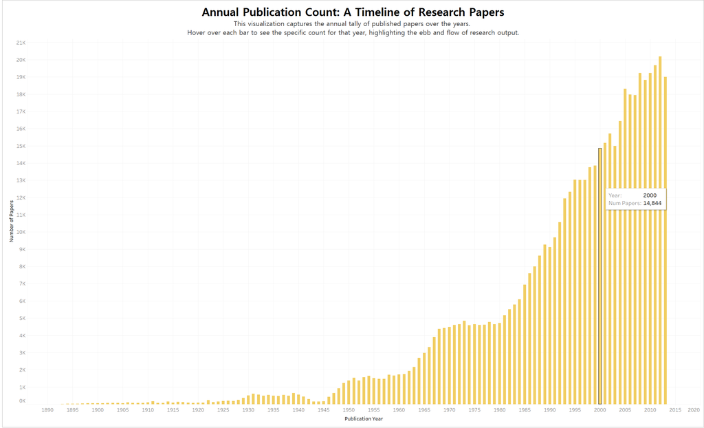

```python
# Annual Publication Count: A Timeline of Research Papers 可视化展示
from IPython.display import Image
Image(filename='Temporal Data Visualization1.png')
```

3、数据处理的过程

```python
import pandas as pd
import jsonlines
import re
```

```python
# 导入 csv 出现警告：第5、7、8列具有混合类型
aps_metadata = pd.read_csv('apsMetadata.csv', dtype={5: 'str', 7: 'str', 8: 'str'})
aps_metadata['pubDate'] = pd.to_datetime(aps_metadata['pubDate'])
aps_metadata
```

|  | doi | articleType | journal | title | pubDate | issueNumber | volumeNumber | pageStart | pageEnd | numPages |
| --- | --- | --- | --- | --- | --- | --- | --- | --- | --- | --- |
| 0 | 10.1103/PhysRev.1.1 | article | Physical Review | Announcement of the Transfer of the Review to ... | 1913-01-01 | 1 | 1 | 1 | 1 | 0.0 |
| 1 | 10.1103/PhysRev.1.124 | article | Physical Review | An Absolute Determination of the Viscosity of Air | 1913-02-01 | 2 | 1 | 124 | 140 | 16.0 |
| 2 | 10.1103/PhysRev.1.141 | article | Physical Review | Determination of the Heat of Solution of Metal... | 1913-02-01 | 2 | 1 | 141 | 153 | 12.0 |
| 3 | 10.1103/PhysRev.1.154 | article | Physical Review | The Electron Theory of Phosphorescence | 1913-02-01 | 2 | 1 | 154 | 160 | 6.0 |
| 4 | 10.1103/PhysRev.1.16 | article | Physical Review | The Velocity of Electrons in the Photo-electri... | 1913-01-01 | 1 | 1 | 16 | 34 | 18.0 |
| ... | ... | ... | ... | ... | ... | ... | ... | ... | ... | ... |
| 541443 | 10.1103/RevModPhys.9.391 | article | Reviews of Modern Physics | The Multiple Ionization of Inner Electron Shel... | 1937-10-01 | 4 | 9 | 391 | 402 | 11.0 |
| 541444 | 10.1103/RevModPhys.9.403 | article | Reviews of Modern Physics | A Survey of the Facts and the Theories of the ... | 1937-10-01 | 4 | 9 | 403 | 431 | 28.0 |
| 541445 | 10.1103/RevModPhys.9.432 | article | Reviews of Modern Physics | Theories of Optical Rotatory Power | 1937-10-01 | 4 | 9 | 432 | 457 | 25.0 |
| 541446 | 10.1103/RevModPhys.9.44 | article | Reviews of Modern Physics | Terrestrial Magnetic Variations and Aurorae | 1937-01-01 | 1 | 9 | 44 | 68 | 24.0 |
| 541447 | 10.1103/RevModPhys.9.69 | article | Reviews of Modern Physics | Nuclear Physics B. Nuclear Dynamics, Theoretical | 1937-04-01 | 2 | 9 | 69 | 244 | 175.0 |

541448 rows × 10 columns

```python
# 提取 pubDate 年份
aps_metadata['year'] = aps_metadata['pubDate'].dt.year
aps_metadata
```

|  | doi | articleType | journal | title | pubDate | issueNumber | volumeNumber | pageStart | pageEnd | numPages | year |
| --- | --- | --- | --- | --- | --- | --- | --- | --- | --- | --- | --- |
| 0 | 10.1103/PhysRev.1.1 | article | Physical Review | Announcement of the Transfer of the Review to ... | 1913-01-01 | 1 | 1 | 1 | 1 | 0.0 | 1913 |
| 1 | 10.1103/PhysRev.1.124 | article | Physical Review | An Absolute Determination of the Viscosity of Air | 1913-02-01 | 2 | 1 | 124 | 140 | 16.0 | 1913 |
| 2 | 10.1103/PhysRev.1.141 | article | Physical Review | Determination of the Heat of Solution of Metal... | 1913-02-01 | 2 | 1 | 141 | 153 | 12.0 | 1913 |
| 3 | 10.1103/PhysRev.1.154 | article | Physical Review | The Electron Theory of Phosphorescence | 1913-02-01 | 2 | 1 | 154 | 160 | 6.0 | 1913 |
| 4 | 10.1103/PhysRev.1.16 | article | Physical Review | The Velocity of Electrons in the Photo-electri... | 1913-01-01 | 1 | 1 | 16 | 34 | 18.0 | 1913 |
| ... | ... | ... | ... | ... | ... | ... | ... | ... | ... | ... | ... |
| 541443 | 10.1103/RevModPhys.9.391 | article | Reviews of Modern Physics | The Multiple Ionization of Inner Electron Shel... | 1937-10-01 | 4 | 9 | 391 | 402 | 11.0 | 1937 |
| 541444 | 10.1103/RevModPhys.9.403 | article | Reviews of Modern Physics | A Survey of the Facts and the Theories of the ... | 1937-10-01 | 4 | 9 | 403 | 431 | 28.0 | 1937 |
| 541445 | 10.1103/RevModPhys.9.432 | article | Reviews of Modern Physics | Theories of Optical Rotatory Power | 1937-10-01 | 4 | 9 | 432 | 457 | 25.0 | 1937 |
| 541446 | 10.1103/RevModPhys.9.44 | article | Reviews of Modern Physics | Terrestrial Magnetic Variations and Aurorae | 1937-01-01 | 1 | 9 | 44 | 68 | 24.0 | 1937 |
| 541447 | 10.1103/RevModPhys.9.69 | article | Reviews of Modern Physics | Nuclear Physics B. Nuclear Dynamics, Theoretical | 1937-04-01 | 2 | 9 | 69 | 244 | 175.0 | 1937 |

541448 rows × 11 columns

```python
# 按年统计发表论文数量
papers_per_year = aps_metadata.groupby('year').size().reset_index(name='num_papers')
papers_per_year.to_csv("year_numpapers.csv", index=False)
papers_per_year
```

|  | year | num_papers |
| --- | --- | --- |
| 0 | 1893 | 20 |
| 1 | 1894 | 36 |
| 2 | 1895 | 36 |
| 3 | 1896 | 36 |
| 4 | 1897 | 54 |
| ... | ... | ... |
| 116 | 2009 | 18826 |
| 117 | 2010 | 19228 |
| 118 | 2011 | 19684 |
| 119 | 2012 | 20190 |
| 120 | 2013 | 18998 |

121 rows × 2 columns

## （2）Temporal Data Visualization

### （2.2）Monthly PACS Breakdown: A Heatmap of Research Publications (1977 - 2013)

### Dataset：apsMetadata.csv, doiPacs.jsonl

1、可视化结果的展示

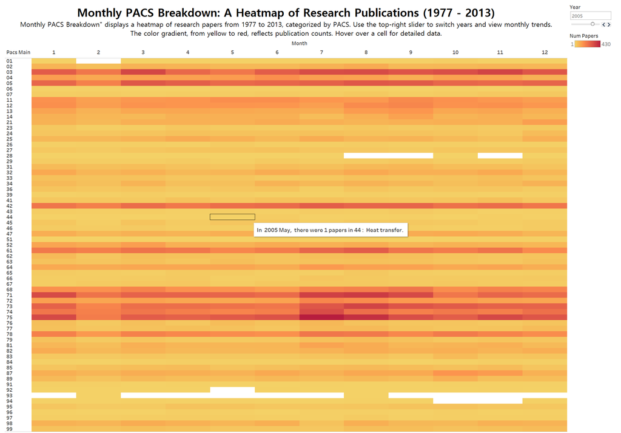

```python
# Monthly PACS Breakdown: A Heatmap of Research Publications (1977 - 2013) 可视化展示
from IPython.display import Image
Image(filename='Temporal Data Visualization2.png')
```

3、数据处理的过程

```python
import pandas as pd
import jsonlines
import re
```

```python
# 导入 csv 出现警告：第5、7、8列具有混合类型
aps_metadata = pd.read_csv('apsMetadata.csv', dtype={5: 'str', 7: 'str', 8: 'str'})
with jsonlines.open('doiPacs.jsonl', mode='r') as reader:
    data_pacs = [item for item in reader]

pacs_df = pd.DataFrame(data_pacs)

# 展开 pacs 列
pacs_df_exploded = pacs_df.explode('pacs')

# 只提取前两位作为主要分类
pacs_df_exploded['pacs_main'] = pacs_df_exploded['pacs'].str[:2]

# 过滤掉非数字条目
pacs_df_exploded = pacs_df_exploded[pacs_df_exploded['pacs_main'].str.isnumeric()]

# 合并数据以获取每篇论文的发表日期和主要 PACS 分类信息
merged_data_pacs = aps_metadata.merge(pacs_df_exploded, on='doi', how='inner')

# 从日期中提取年份和月份
merged_data_pacs['year'] = pd.to_datetime(merged_data_pacs['pubDate']).dt.year
merged_data_pacs['month'] = pd.to_datetime(merged_data_pacs['pubDate']).dt.month

# 按月和 PACS 主分类计算论文数量
papers_per_month_per_pacs = merged_data_pacs.groupby(['year', 'month', 'pacs_main']).size().reset_index(name='num_papers')
papers_per_month_per_pacs.to_csv("month_pacs.csv", index=False)
```

```python
papers_per_month_per_pacs
```

|  | year | month | pacs_main | num_papers |
| --- | --- | --- | --- | --- |
| 0 | 1977 | 6 | 21 | 1 |
| 1 | 1977 | 6 | 27 | 2 |
| 2 | 1977 | 9 | 71 | 3 |
| 3 | 1977 | 9 | 78 | 1 |
| 4 | 1977 | 9 | 79 | 1 |
| ... | ... | ... | ... | ... |
| 24236 | 2013 | 12 | 95 | 56 |
| 24237 | 2013 | 12 | 96 | 6 |
| 24238 | 2013 | 12 | 97 | 16 |
| 24239 | 2013 | 12 | 98 | 69 |
| 24240 | 2013 | 12 | 99 | 44 |

24241 rows × 4 columns

```python
# 发现没有缺失值
papers_per_month_per_pacs.isnull().sum()
```

```
year          0
month         0
pacs_main     0
num_papers    0
dtype: int64
```

```python
# pacs_main 在01至99范围内
print(papers_per_month_per_pacs['pacs_main'].min())
print(papers_per_month_per_pacs['pacs_main'].max())
```

```
01
99
```

```python
# 将每个月份的英文名字保存至字典中
month_dict = {
    1: "January",
    2: "February",
    3: "March",
    4: "April",
    5: "May",
    6: "June",
    7: "July",
    8: "August",
    9: "September",
    10: "October",
    11: "November",
    12: "December"
}
```

```python
# 将每个 PACS 大类的英文名字保存至字典中
# 有的像35,37,88,19,53,38,22,55在 PACS 分类表中没有英文名字，用 Unknown 替代
# PACS 99号没有英文名字，用 99.10.Àx Errata and other corrections 替代
pacs_dict = {
    "01": "Communication, education, history, and philosophy",
    "02": "Mathematical methods in physics",
    "03": "Quantum mechanics, field theories, and special relativity",
    "04": "General relativity and gravitation",
    "05": "Statistical physics, thermodynamics, and nonlinear dynamical systems",
    "06": "Metrology, measurements, and laboratory procedures",
    "07": "Instruments, apparatus, and components common to several branches of physics and astronomy",
    "11": "General theory of fields and particles",
    "12": "Specific theories and interaction models; particle systematics",
    "13": "Specific reactions and phenomenology",
    "14": "Properties of specific particles",
    "21": "Nuclear structure",
    "23": "Radioactive decay and in-beam spectroscopy",
    "24": "Nuclear reactions: general",
    "25": "Nuclear reactions: specific reactions",
    "26": "Nuclear astrophysics",
    "27": "Properties of specific nuclei listed by mass ranges",
    "28": "Nuclear engineering and nuclear power studies",
    "29": "Experimental methods and instrumentation for elementary particle and nuclear physics",
    "31": "Electronic structure of atoms and molecules: theory",
    "32": "Atomic properties and interactions with photons",
    "33": "Molecular properties and interactions with photons",
    "34": "Atomic and molecular collision processes and interactions",
    "36": "Exotic atoms and molecules; macromolecules; clusters",
    "39": "Instrumentation and techniques for atomic and molecular physics",
    "41": "Electromagnetism; electron and ion optics",
    "42": "Optics",
    "43": "Acoustics",
    "44": "Heat transfer",
    "45": "Classical mechanics of discrete systems",
    "46": "Continuum mechanics of solids",
    "47": "Fluid dynamics",
    "51": "Physics of gases",
    "52": "Physics of plasmas and electric discharges",
    "61": "Structure of solids and liquids; crystallography",
    "62": "Mechanical and acoustical properties of condensed matter",
    "63": "Lattice dynamics",
    "64": "Equations of state, phase equilibria, and phase transitions",
    "65": "Thermal properties of condensed matter",
    "66": "Transport properties of condensed matter (nonelectronic)",
    "67": "Quantum fluids and solids; liquid and solid helium",
    "68": "Surfaces and interfaces; thin films and low-dimensional systems (structure and nonelectronic properties)",
    "71": "Electronic structure of bulk materials",
    "72": "Electronic transport in condensed matter",
    "73": "Electronic structure and electrical properties of surfaces, interfaces, thin films, and low-dimensional structures",
    "74": "Superconductivity",
    "75": "Magnetic properties and materials",
    "76": "Magnetic resonances and relaxations in condensed matter, Mössbauer effect",
    "77": "Dielectrics, piezoelectrics, and ferroelectrics and their properties",
    "78": "Optical properties, condensed matter spectroscopy and other interactions of radiation and particles with condensed matter",
    "79": "Electron and ion emission by liquids and solids; impact phenomena",
    "81": "Materials science",
    "82": "Physical chemistry and chemical physics",
    "83": "Rheology",
    "84": "Electronics; radiowave and microwave technology; direct energy conversion and storage",
    "85": "Electronic and magnetic devices; microelectronics",
    "87": "Biological and medical physics",
    "89": "Other areas of applied and interdisciplinary physics",
    "91": "Solid Earth physics",
    "92": "Hydrospheric and atmospheric geophysics",
    "93": "Geophysical observations, instrumentation, and techniques",
    "94": "Aeronomy and magnetospheric physics",
    "95": "Fundamental astronomy and astrophysics; instrumentation, techniques, and astronomical observations",
    "96": "Solar System",
    "97": "Stars",
    "98": "Stellar systems; interstellar medium; galactic and extragalactic objects and systems; the Universe",
    "99": "Errata and other corrections",
    "35": "Unknown",
    "37": "Unknown",
    "88": "Unknown",
    "19": "Unknown",
    "53": "Unknown",
    "38": "Unknown",
    "22": "Unknown",
    "30": "Atomic and molecular physic",
    "70": "Condensed matter: electronic structure, electrical, magnetic, and optical properties",
    "20": "Nuclear physics",
    "60": "Condensed matter: structural, mechanical and thermal properties",
    "40": "Electromagnetism, optics, acoustics, heat transfer, classical mechanics, and fluid mechanics",
    "55": "Unknown",
    "10": "The physics of elementary particles and fields",
    "90": "Geophysics, astronomy, and astrophysics"
}

# 将 month_dict, pacs_dict 分别映射到 month, pacs_main
# 这样做的目的是，提高鼠标悬停效果
# 鼠标悬停在某个块上，显示：In 1977 June, there were 1 paper in PACS 21: Nuclear structure.
papers_per_month_per_pacs['month_spec'] = papers_per_month_per_pacs['month'].map(month_dict)
papers_per_month_per_pacs['pacs_spec'] = papers_per_month_per_pacs['pacs_main'].map(pacs_dict)
papers_per_month_per_pacs.to_csv("month_pacs.csv", index=False)
```

```python
papers_per_month_per_pacs
```

|  | year | month | pacs_main | num_papers | month_spec | pacs_spec |
| --- | --- | --- | --- | --- | --- | --- |
| 0 | 1977 | 6 | 21 | 1 | June | Nuclear structure |
| 1 | 1977 | 6 | 27 | 2 | June | Properties of specific nuclei listed by mass r... |
| 2 | 1977 | 9 | 71 | 3 | September | Electronic structure of bulk materials |
| 3 | 1977 | 9 | 78 | 1 | September | Optical properties, condensed matter spectrosc... |
| 4 | 1977 | 9 | 79 | 1 | September | Electron and ion emission by liquids and solid... |
| ... | ... | ... | ... | ... | ... | ... |
| 24236 | 2013 | 12 | 95 | 56 | December | Fundamental astronomy and astrophysics; instru... |
| 24237 | 2013 | 12 | 96 | 6 | December | Solar System |
| 24238 | 2013 | 12 | 97 | 16 | December | Stars |
| 24239 | 2013 | 12 | 98 | 69 | December | Stellar systems; interstellar medium; galactic... |
| 24240 | 2013 | 12 | 99 | 44 | December | Errata and other corrections |

24241 rows × 6 columns

```python
# 发现没有缺失值
papers_per_month_per_pacs.isnull().sum()
```

```
year          0
month         0
pacs_main     0
num_papers    0
month_spec    0
pacs_spec     0
dtype: int64
```